# Project: Investigate TMDb Movie Data

- Introduction
- Data Wrangling
- Exploratory Data Analysis
- Conclusions

## Introduction

> In this project, TMDb movie data set was analysed. The data set consists of information about 10,000 movies from 1966 to 2015 which includes budget, vote_count, revenue earned, runtime etc.

> Questions that can be answered from this data set are:
> 1. Which movies earned the highest and lowest profit?
> 2. Which movies had the highest and lowest budget?
> 3. Which movies had earned the maximum and minimum revenue?
> 4. Which movie had the highest and lowest runtime?
> 5. What is the average runtime of all the movies from 1966 to 2015?
> 6. What properties are associated with the revenue earned and popularity of a movie?
> 7. Which genres had the highest release?
> 8. Who were the most frequent actors?

```python
# Use this cell to set up import statements for all of the packages that you
#   plan to use.

# Remember to include a 'magic word' so that your visualizations are plotted
#   inline with the notebook. See this page for more:
#   http://ipython.readthedocs.io/en/stable/interactive/magics.html

import pandas as pd
import numpy as np
import matplotlib.pyplot as plt
from datetime import datetime
%matplotlib inline
```

## Data Wrangling

> The CSV file containing the data was observed and it was found that there were a number of columns which were not relevant for addressing the questions listed above. Therefore, only relevant data were kept for carrying out the analysis.

### General Properties

```python
# Load your data and print out a few lines. Perform operations to inspect data
#   types and look for instances of missing or possibly errant data.

tmdb_data = pd.read_csv('tmdb_movies.csv')

#printing first five rows of the data set
tmdb_data.head()
```

|  | id | imdb_id | popularity | budget | revenue | original_title | cast | homepage | director | tagline | ... | overview | runtime | genres | production_companies | release_date | vote_count | vote_average | release_year | budget_adj | revenue_adj |
| --- | --- | --- | --- | --- | --- | --- | --- | --- | --- | --- | --- | --- | --- | --- | --- | --- | --- | --- | --- | --- | --- |
| 0 | 135397 | tt0369610 | 32.985763 | 150000000 | 1513528810 | Jurassic World | Chris Pratt\|Bryce Dallas Howard\|Irrfan Khan\|Vi... | http://www.jurassicworld.com/ | Colin Trevorrow | The park is open. | ... | Twenty-two years after the events of Jurassic ... | 124 | Action\|Adventure\|Science Fiction\|Thriller | Universal Studios\|Amblin Entertainment\|Legenda... | 06/9/15 | 5562 | 6.5 | 2015.0 | 137999939.3 | 1392445893 |
| 1 | 76341 | tt1392190 | 28.419936 | 150000000 | 378436354 | Mad Max: Fury Road | Tom Hardy\|Charlize Theron\|Hugh Keays-Byrne\|Nic... | http://www.madmaxmovie.com/ | George Miller | What a Lovely Day. | ... | An apocalyptic story set in the furthest reach... | 120 | Action\|Adventure\|Science Fiction\|Thriller | Village Roadshow Pictures\|Kennedy Miller Produ... | 05/13/15 | 6185 | 7.1 | 2015.0 | 137999939.3 | 348161292.5 |
| 2 | 262500 | tt2908446 | 13.112507 | 110000000 | 295238201 | Insurgent | Shailene Woodley\|Theo James\|Kate Winslet\|Ansel... | http://www.thedivergentseries.movie/#insurgent | Robert Schwentke | One Choice Can Destroy You | ... | Beatrice Prior must confront her inner demons ... | 119 | Adventure\|Science Fiction\|Thriller | Summit Entertainment\|Mandeville Films\|Red Wago... | 03/18/15 | 2480 | 6.3 | 2015.0 | 101199955.5 | 271619025.4 |
| 3 | 140607 | tt2488496 | 11.173104 | 200000000 | 2068178225 | Star Wars: The Force Awakens | Harrison Ford\|Mark Hamill\|Carrie Fisher\|Adam D... | http://www.starwars.com/films/star-wars-episod... | J.J. Abrams | Every generation has a story. | ... | Thirty years after defeating the Galactic Empi... | 136 | Action\|Adventure\|Science Fiction\|Fantasy | Lucasfilm\|Truenorth Productions\|Bad Robot | 12/15/15 | 5292 | 7.5 | 2015.0 | 183999919.0 | 1902723130 |
| 4 | 168259 | tt2820852 | 9.335014 | 190000000 | 1506249360 | Furious 7 | Vin Diesel\|Paul Walker\|Jason Statham\|Michelle ... | http://www.furious7.com/ | James Wan | Vengeance Hits Home | ... | Deckard Shaw seeks revenge against Dominic Tor... | 137 | Action\|Crime\|Thriller | Universal Pictures\|Original Film\|Media Rights ... | 04/1/15 | 2947 | 7.3 | 2015.0 | 174799923.1 | 1385748801 |

5 rows × 21 columns

```python
# check for number of rows and columns in the data set
tmdb_data.shape
```

```
(10879, 21)
```

### Data Cleaning (Removing unused columns from the data set )

#### Steps taken to clean the data

1. Columns such as id, imdb_id, homepage, tagline, overview, production companies, vote_count etc. were removed from the data set.
2. Duplicate data were checked and if present they were removed.
3. Removed the null values from the data set.
4. Changed the format of release date column to date format.
5. Changed the format of budget, revenue and runtime column.
6. Discarding rows of budget and revenue with 0's.
7. Replacing 0's with NaN in runtime column.

#### 1. Removing columns which are not needed for the analysis

#### Columns which are deleted are id, imdb_id, homepage, tagline, keywords, overview, production_companies, vote_count, vote_average, budget_adj and revenue_adj

```python
# List of column to be deleted
del_col = ['id', 'imdb_id', 'homepage', 'tagline', 'keywords', 'overview', 'production_companies', 'vote_count', 'vote_average', 'budget_adj', 'revenue_adj']

#delete the columns
tmdb_data = tmdb_data.drop(del_col,1)

#check the new data set
tmdb_data.head()
```

|  | popularity | budget | revenue | original_title | cast | director | runtime | genres | release_date | release_year |
| --- | --- | --- | --- | --- | --- | --- | --- | --- | --- | --- |
| 0 | 32.985763 | 150000000 | 1513528810 | Jurassic World | Chris Pratt\|Bryce Dallas Howard\|Irrfan Khan\|Vi... | Colin Trevorrow | 124 | Action\|Adventure\|Science Fiction\|Thriller | 06/9/15 | 2015.0 |
| 1 | 28.419936 | 150000000 | 378436354 | Mad Max: Fury Road | Tom Hardy\|Charlize Theron\|Hugh Keays-Byrne\|Nic... | George Miller | 120 | Action\|Adventure\|Science Fiction\|Thriller | 05/13/15 | 2015.0 |
| 2 | 13.112507 | 110000000 | 295238201 | Insurgent | Shailene Woodley\|Theo James\|Kate Winslet\|Ansel... | Robert Schwentke | 119 | Adventure\|Science Fiction\|Thriller | 03/18/15 | 2015.0 |
| 3 | 11.173104 | 200000000 | 2068178225 | Star Wars: The Force Awakens | Harrison Ford\|Mark Hamill\|Carrie Fisher\|Adam D... | J.J. Abrams | 136 | Action\|Adventure\|Science Fiction\|Fantasy | 12/15/15 | 2015.0 |
| 4 | 9.335014 | 190000000 | 1506249360 | Furious 7 | Vin Diesel\|Paul Walker\|Jason Statham\|Michelle ... | James Wan | 137 | Action\|Crime\|Thriller | 04/1/15 | 2015.0 |

```python
tmdb_data.shape
```

```
(10879, 10)
```

#### 2. Checking for duplicate rows and if present deleting them

```python
# Check for duplicate rows
sum(tmdb_data.duplicated())
```

```
1
```

```python
# Drop the duplicate rows
tmdb_data.drop_duplicates(inplace=True)
```

```python
# Check for duplicate rows again
sum(tmdb_data.duplicated())
```

```
0
```

#### 3. Removing the null values

```python
# Checking the columns for null values in the data set
tmdb_data.isnull().sum()
```

```
popularity         0
budget             2
revenue            3
original_title     4
cast              80
director          47
runtime           19
genres            45
release_date      22
release_year      22
dtype: int64
```

```python
# Removing the null values in the data set
tmdb_data.dropna(subset=['budget','revenue','original_title','cast','director','runtime','genres','release_date', 'release_year'], how='any', inplace = True)
tmdb_data.isnull().sum()
```

```
popularity        0
budget            0
revenue           0
original_title    0
cast              0
director          0
runtime           0
genres            0
release_date      0
release_year      0
dtype: int64
```

```python
# check for number of rows and columns of the data set after removing the null values
tmdb_data.shape
```

```
(10722, 10)
```

```python
# Check for individual columns for null values
tmdb_data.info()
```

```
<class 'pandas.core.frame.DataFrame'>
Int64Index: 10722 entries, 0 to 10878
Data columns (total 10 columns):
popularity        10722 non-null object
budget            10722 non-null object
revenue           10722 non-null object
original_title    10722 non-null object
cast              10722 non-null object
director          10722 non-null object
runtime           10722 non-null object
genres            10722 non-null object
release_date      10722 non-null object
release_year      10722 non-null float64
dtypes: float64(1), object(9)
memory usage: 921.4+ KB
```

#### 4. Changing the format of release date to date format

```python
# Changing the format of release date to date format
tmdb_data['release_date'] = pd.to_datetime(tmdb_data['release_date'], errors='coerce')

# Checking the format of release date column
tmdb_data.head()
```

|  | popularity | budget | revenue | original_title | cast | director | runtime | genres | release_date | release_year |
| --- | --- | --- | --- | --- | --- | --- | --- | --- | --- | --- |
| 0 | 32.985763 | 150000000 | 1513528810 | Jurassic World | Chris Pratt\|Bryce Dallas Howard\|Irrfan Khan\|Vi... | Colin Trevorrow | 124 | Action\|Adventure\|Science Fiction\|Thriller | 2015-06-09 | 2015.0 |
| 1 | 28.419936 | 150000000 | 378436354 | Mad Max: Fury Road | Tom Hardy\|Charlize Theron\|Hugh Keays-Byrne\|Nic... | George Miller | 120 | Action\|Adventure\|Science Fiction\|Thriller | 2015-05-13 | 2015.0 |
| 2 | 13.112507 | 110000000 | 295238201 | Insurgent | Shailene Woodley\|Theo James\|Kate Winslet\|Ansel... | Robert Schwentke | 119 | Adventure\|Science Fiction\|Thriller | 2015-03-18 | 2015.0 |
| 3 | 11.173104 | 200000000 | 2068178225 | Star Wars: The Force Awakens | Harrison Ford\|Mark Hamill\|Carrie Fisher\|Adam D... | J.J. Abrams | 136 | Action\|Adventure\|Science Fiction\|Fantasy | 2015-12-15 | 2015.0 |
| 4 | 9.335014 | 190000000 | 1506249360 | Furious 7 | Vin Diesel\|Paul Walker\|Jason Statham\|Michelle ... | James Wan | 137 | Action\|Crime\|Thriller | 2015-04-01 | 2015.0 |

#### 5. Changing the format of budget, revenue and runtime

```python
# Changing the format of budget, revenue and runtime
tmdb_data['budget'] = pd.to_numeric(tmdb_data.budget, errors='coerce').fillna(0).astype(int)
tmdb_data['revenue'] = pd.to_numeric(tmdb_data.revenue, errors='coerce').fillna(0).astype(int)
tmdb_data['runtime'] = pd.to_numeric(tmdb_data.runtime, errors='coerce').fillna(0).astype(int)
```

```python
# Checking the new format of budget, revenue and runtime
tmdb_data.info()
```

```
<class 'pandas.core.frame.DataFrame'>
Int64Index: 10722 entries, 0 to 10878
Data columns (total 10 columns):
popularity        10722 non-null object
budget            10722 non-null int64
revenue           10722 non-null int64
original_title    10722 non-null object
cast              10722 non-null object
director          10722 non-null object
runtime           10722 non-null int64
genres            10722 non-null object
release_date      10721 non-null datetime64[ns]
release_year      10722 non-null float64
dtypes: datetime64[ns](1), float64(1), int64(3), object(5)
memory usage: 921.4+ KB
```

#### 6. Discarding rows of budget and revenue with 0's

```python
# creating a temporary list of revenue and budget column
temp_list=['budget', 'revenue']

# Replacing '0' to NAN in the list
tmdb_data[temp_list] = tmdb_data[temp_list].replace(0, np.NAN)

#Removing all the row with NaN value in the temp_list
tmdb_data.dropna(subset = temp_list, inplace = True)
```

```python
# checking number of rows and columns after the cleaning process
tmdb_data.shape
```

```
(3848, 10)
```

#### 7. Replacing 0's with NaN in runtime column

```python
#replacing 0's with NaN in runtime column in the dataset
tmdb_data['runtime'] =tmdb_data['runtime'].replace(0, np.NAN)
```

```python
# Saving the clean data as a new file
tmdb_data.to_csv('tmdb_movies_clean.csv', index=False)
```

## Exploratory Data Analysis

### Research Question 1. Which movies earned the highest and lowest profit?

```python
# Load the new file created on the previous step
df_tmdb = pd.read_csv('tmdb_movies_clean.csv')

# Calculating the profit earned for each movie
df_tmdb.insert(3, 'profit', df_tmdb['revenue']-df_tmdb['budget'])

# checking the new column in the data set
df_tmdb.head()
```

|  | popularity | budget | revenue | profit | original_title | cast | director | runtime | genres | release_date | release_year |
| --- | --- | --- | --- | --- | --- | --- | --- | --- | --- | --- | --- |
| 0 | 32.985763 | 150000000.0 | 1.513529e+09 | 1.363529e+09 | Jurassic World | Chris Pratt\|Bryce Dallas Howard\|Irrfan Khan\|Vi... | Colin Trevorrow | 124 | Action\|Adventure\|Science Fiction\|Thriller | 2015-06-09 | 2015.0 |
| 1 | 28.419936 | 150000000.0 | 3.784364e+08 | 2.284364e+08 | Mad Max: Fury Road | Tom Hardy\|Charlize Theron\|Hugh Keays-Byrne\|Nic... | George Miller | 120 | Action\|Adventure\|Science Fiction\|Thriller | 2015-05-13 | 2015.0 |
| 2 | 13.112507 | 110000000.0 | 2.952382e+08 | 1.852382e+08 | Insurgent | Shailene Woodley\|Theo James\|Kate Winslet\|Ansel... | Robert Schwentke | 119 | Adventure\|Science Fiction\|Thriller | 2015-03-18 | 2015.0 |
| 3 | 11.173104 | 200000000.0 | 2.068178e+09 | 1.868178e+09 | Star Wars: The Force Awakens | Harrison Ford\|Mark Hamill\|Carrie Fisher\|Adam D... | J.J. Abrams | 136 | Action\|Adventure\|Science Fiction\|Fantasy | 2015-12-15 | 2015.0 |
| 4 | 9.335014 | 190000000.0 | 1.506249e+09 | 1.316249e+09 | Furious 7 | Vin Diesel\|Paul Walker\|Jason Statham\|Michelle ... | James Wan | 137 | Action\|Crime\|Thriller | 2015-04-01 | 2015.0 |

```python
#defining the function
def calculate(column):
    #for highest earned profit
    highest= df_tmdb[column].idxmax()
    highest_details=pd.DataFrame(df_tmdb.loc[highest])

    #for lowest earned profit
    lowest= df_tmdb[column].idxmin()
    lowest_details=pd.DataFrame(df_tmdb.loc[lowest])

    #collectin data in one place
    details=pd.concat([highest_details, lowest_details], axis=1)

    return details

calculate('profit')
```

|  | 343 | 681 |
| --- | --- | --- |
| popularity | 9.43277 | 0.25054 |
| budget | 2.37e+08 | 4.25e+08 |
| revenue | 2.78151e+09 | 1.10876e+07 |
| profit | 2.54451e+09 | -4.13912e+08 |
| original_title | Avatar | The Warrior's Way |
| cast | Sam Worthington\|Zoe Saldana\|Sigourney Weaver\|S... | Kate Bosworth\|Jang Dong-gun\|Geoffrey Rush\|Dann... |
| director | James Cameron | Sngmoo Lee |
| runtime | 162 | 100 |
| genres | Action\|Adventure\|Fantasy\|Science Fiction | Adventure\|Fantasy\|Action\|Western\|Thriller |
| release_date | 2009-12-10 | 2010-12-02 |
| release_year | 2009 | 2010 |

#### So, from the analysis it can be seen that the movie 'Avatar' has earned the highest profit of 2544.51 million dollar. Whereas, the movie 'The Warrior's Way' has earned the least profit of -413.912 million dollar.

### Research Question 2. Which movie had the highest and lowest budget?

```python
# To calculate the highest and lowest budget, the same function calculate(column) is called

calculate('budget')
```

|  | 681 | 809 |
| --- | --- | --- |
| popularity | 0.25054 | 0.090186 |
| budget | 4.25e+08 | 1 |
| revenue | 1.10876e+07 | 100 |
| profit | -4.13912e+08 | 99 |
| original_title | The Warrior's Way | Lost &amp; Found |
| cast | Kate Bosworth\|Jang Dong-gun\|Geoffrey Rush\|Dann... | David Spade\|Sophie Marceau\|Ever Carradine\|Step... |
| director | Sngmoo Lee | Jeff Pollack |
| runtime | 100 | 95 |
| genres | Adventure\|Fantasy\|Action\|Western\|Thriller | Comedy\|Romance |
| release_date | 2010-12-02 | 1999-04-23 |
| release_year | 2010 | 1999 |

#### It can be depicted from the above analysis that the movie 'The Warrior's Way' had the highest budget of 425 million dollar and the movie 'Lost & Found' had the lowest budget of 1 dollar.

### Research Question 3. Which movie had earned the highest and lowest revenue?

```python
# For this analysis the function calculate(column) has been called again

calculate('revenue')
```

|  | 343 | 1728 |
| --- | --- | --- |
| popularity | 9.43277 | 0.462609 |
| budget | 2.37e+08 | 6e+06 |
| revenue | 2.78151e+09 | 2 |
| profit | 2.54451e+09 | -6e+06 |
| original_title | Avatar | Shattered Glass |
| cast | Sam Worthington\|Zoe Saldana\|Sigourney Weaver\|S... | Hayden Christensen\|Peter Sarsgaard\|ChloÃ« Sevi... |
| director | James Cameron | Billy Ray |
| runtime | 162 | 94 |
| genres | Action\|Adventure\|Fantasy\|Science Fiction | Drama\|History |
| release_date | 2009-12-10 | 2003-11-14 |
| release_year | 2009 | 2003 |

#### The above analysis showed that the movie 'Avatar' had the highest earned revenue of 2781.51 million dollar and the movie 'Shattered Glass' had earned the lowest revenue of 2 dollar.

### Research Question 4. Which movie has the highest and lowest runtime?

```python
# For this analysis the function calculate(column) has been called again

calculate('runtime')
```

|  | 652 | 1754 |
| --- | --- | --- |
| popularity | 0.534192 | 0.208637 |
| budget | 1.8e+07 | 10 |
| revenue | 871279 | 5 |
| profit | -1.71287e+07 | -5 |
| original_title | Carlos | Kid's Story |
| cast | Edgar RamÃrez\|Alexander Scheer\|Fadi Abi Samra... | Clayton Watson\|Keanu Reeves\|Carrie-Anne Moss\|K... |
| director | Olivier Assayas | Shinichiro Watanabe |
| runtime | 338 | 15 |
| genres | Crime\|Drama\|Thriller\|History | Science Fiction\|Animation |
| release_date | 2010-05-19 | 2003-06-02 |
| release_year | 2010 | 2003 |

#### The above analysis showed that the movie 'Carlos' had the highest runtime of 338 minutes and the movie 'Kid's Story' had the lowest runtime of 15 minutes.

### Research Question 5. What is the average runtime of all the movies from 1966 to 2015?

```python
# Defining function to calculate average of a column
def average(column):
    return df_tmdb[column].mean()

# calling the function
average('runtime')
```

```
109.2195945945946
```

#### The result shows that the average runtime of all the movies is 109 minutes.

#### Plotting the runtime of all the movies from 1966 to 2015

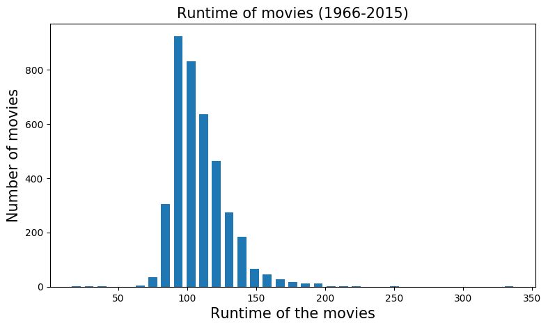

```python
# Plotting a histogram of runtime of all movies
plt.figure(figsize=(9,5), dpi = 100)
plt.xlabel('Runtime of the movies', fontsize=15)
plt.ylabel('Number of movies', fontsize=15)
plt.title('Runtime of movies (1966-2015)', fontsize=15)
plt.hist(df_tmdb['runtime'], rwidth = 0.7, bins = 35)
plt.show()
```

#### The histogram of runtime of movies showed that it is skewed to the right. Maximum number of movies have a runtime of 80 - 115 minutes.

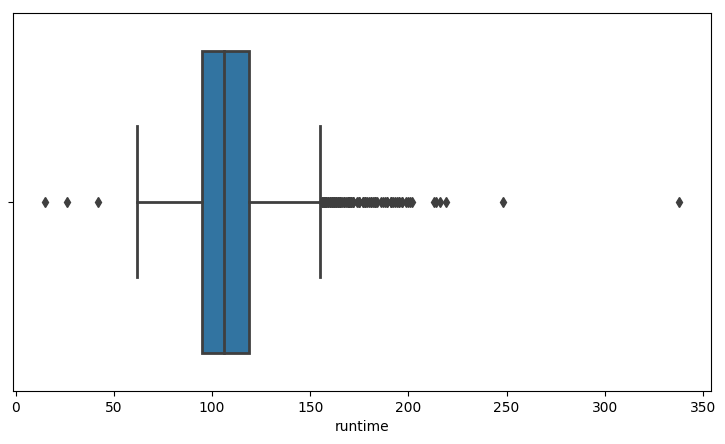

```python
# Plotting a boxplot for the runtime of the movie
plt.figure(figsize=(9,5), dpi = 100)
import seaborn as sns
sns.boxplot(df_tmdb['runtime'], linewidth = 2)
plt.show()
```

#### The boxplot showed that the median of the runtimr of all movies is 106 minutes. The inter-quartile range falls between 95 - 120 mintures. There are more outliers for longer runtime and few for shorter runtime.

### Research Question 6. What properties are associated with the revenue earned and popularity of a movie?

```python
# Correlation of the columns
df_tmdb.corr()
```

|  | popularity | budget | revenue | profit | runtime | release_year |
| --- | --- | --- | --- | --- | --- | --- |
| popularity | 1.000000 | 0.446592 | 0.615363 | 0.596090 | 0.215539 | 0.173566 |
| budget | 0.446592 | 1.000000 | 0.688402 | 0.526660 | 0.261462 | 0.268626 |
| revenue | 0.615363 | 0.688402 | 1.000000 | 0.979139 | 0.250718 | 0.139393 |
| profit | 0.596090 | 0.526660 | 0.979139 | 1.000000 | 0.220592 | 0.088115 |
| runtime | 0.215539 | 0.261462 | 0.250718 | 0.220592 | 1.000000 | -0.112848 |
| release_year | 0.173566 | 0.268626 | 0.139393 | 0.088115 | -0.112848 | 1.000000 |

#### The result shows that popularity has a strong correlation with revenue and profit and moderate correlation with budget. Revenue has a strong correlation with popularity, budget and profit. Both have weak correlation with runtime.

#### Analyzing visually the correlation of popularity and revenue with each individual parameters

[figure not shown]

```python
# Plotting scatterplot of Popularity vs Revenue
plt.figure(figsize=(9,5), dpi = 100)
sns.regplot(x = df_tmdb['popularity'], y = df_tmdb['revenue'])
plt.xlabel('Revenue', fontsize = 15)
plt.ylabel('Popularity', fontsize = 15)
plt.show()
```

#### The scatterplot above showed that the popularity of a movie has a positive correlation with the revenue earned by the movie.

[figure not shown]

```python
# Plotting scatterplot of Popularity vs Budget
plt.figure(figsize=(9,5), dpi = 100)
sns.regplot(x = df_tmdb['popularity'], y = df_tmdb['budget'])
plt.xlabel('Budget', fontsize = 15)
plt.ylabel('Popularity', fontsize = 15)
plt.show()
```

#### The above scatterplot showed that the popularity of a movie has a positive correlation with the budget of the movie.

[figure not shown]

```python
# Plotting scatterplot of Popularity vs Runtime
plt.figure(figsize=(9,5), dpi = 100)
sns.regplot(x = df_tmdb['popularity'], y = df_tmdb['runtime'])
plt.xlabel('Runtime', fontsize = 15)
plt.ylabel('Popularity', fontsize = 15)
plt.show()
```

#### The scatterplot showed above depicted that the popularity of a movie has a weak positive correlation with the runtime of the movie.

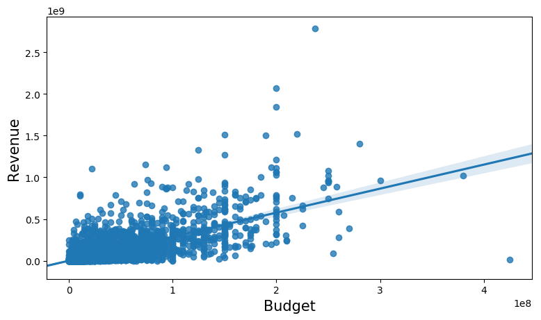

```python
# Plotting scatterplot of Revenue vs Budget
plt.figure(figsize=(9,5), dpi = 100)
sns.regplot(x = df_tmdb['budget'], y = df_tmdb['revenue'])
plt.xlabel('Budget', fontsize = 15)
plt.ylabel('Revenue', fontsize = 15)
plt.show()
```

#### The scatterplot showed above portrayed that the revenue earned by a movie has a positive correlation with the budget of the movie.

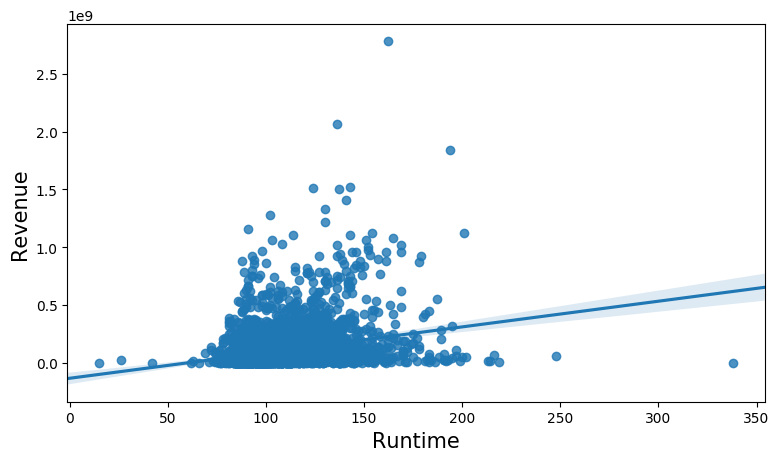

```python
# Plotting scatterplot of Revenue vs Runtime
plt.figure(figsize=(9,5), dpi = 100)
sns.regplot(x = df_tmdb['runtime'], y = df_tmdb['revenue'])
plt.xlabel('Runtime', fontsize = 15)
plt.ylabel('Revenue', fontsize = 15)
plt.show()
```

#### The above figure portrayed that the revenue earned by a movie has a very weak positive correlation with the runtime of the movie.

### Research Question 7. Which genres had the highest release?

```python
def calculate_count(column):
    # Convert column to string and seperate it by '|'
    data = df_tmdb[column].str.cat(sep = '|')

    # Storing the values seperately in a Pandas series
    data = pd.Series(data.split('|'))
    count = data.value_counts(ascending = False)

    return count
```

```python
#variable to store the retured value#variabl
count = calculate_count('genres')

#printing top 5 values
count.head()
```

```
Drama        1753
Comedy       1356
Thriller     1203
Action       1085
Adventure     749
dtype: int64
```

```
Text(0,0.5,'No. of release from 1966-2015')
```

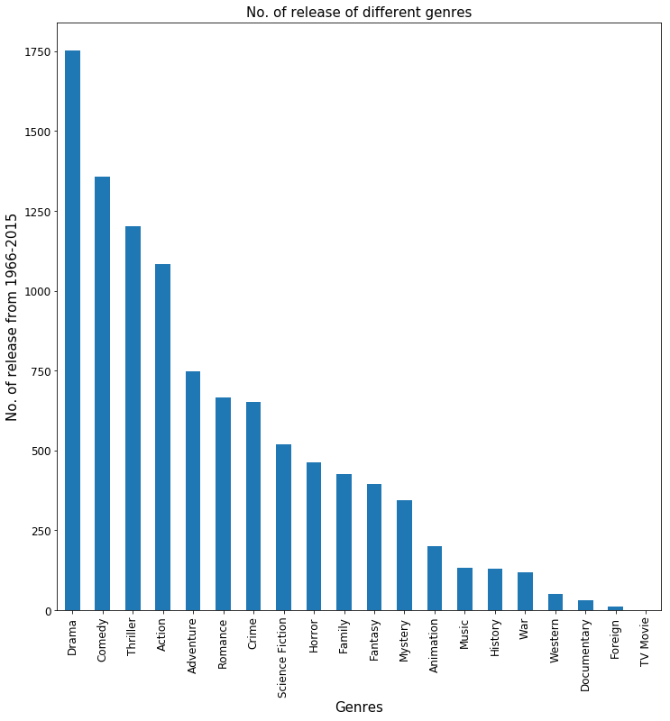

```python
ax = count.plot(kind='bar', figsize = (12, 12), fontsize = 12)
ax.set_title("No. of release of different genres", fontsize = 15)
ax.set_xlabel("Genres", fontsize = 15)
ax.set_ylabel("No. of release from 1966-2015", fontsize = 15)
```

#### It can be seen from the above figure that Drama had the highest release whereas TV Movie had the lowest release during 1966-2015.

### Research Question 8. Who were the most frequent actors?

```
Morgan Freeman        34
Sylvester Stallone    34
Harrison Ford         34
Brad Pitt             34
Johnny Depp           35
Matt Damon            36
Nicolas Cage          43
Samuel L. Jackson     44
Bruce Willis          46
Robert De Niro        52
dtype: int64
```

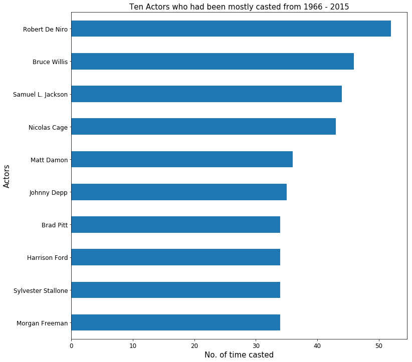

```python
actor = df_tmdb["cast"].str.cat(sep="|").split("|")

table=pd.Series(actor).value_counts(ascending=True)[-10:]
graph = table.plot(kind='barh', figsize = (12, 12), fontsize = 12)
graph.set_title("Ten Actors who had been mostly casted from 1966 - 2015", fontsize = 15)
graph.set_xlabel("No. of time casted", fontsize = 15)
graph.set_ylabel("Actors", fontsize = 15)
print(table)
```

#### The above figure shows en actors who had been casted the maximum time with Robert De Niro as top of the chart. He had been casted 52 times during 1966-2015.

## Conclusions

#### The TMDb movie data was analysed in this analysis. It was found that the popularity of a movie has a strong correlation with revenue earned and profit and moderate correlation with budget. The Revenue earned has a strong correlation with popularity, budget and profit. It was also depicted from the analysis that amongst the genres, Drama had been released the maximum number of times and Robert De Niro was the mostly casted actor.

#### Although some important informations were retrieved from the data set, it has some limitations.

### Limitations

#### 1. The budget and revenue supplied in the data set have no information about the currency. It was assumed that they are in US Dollar. However, the data might change if the currencies are different.

#### 2. The 0 values and NaN values were discarded from the data set. It had reduced the number of data present in the data set significantly, which might had effected the statistical analysis.

```python
from subprocess import call
call(['python', '-m', 'nbconvert', 'Investigate_a_Dataset.ipynb'])
```